# O Pacote dplyr e o operador pipe

Alessandro Freire

02 maio, 2019

# Introdução

- O `dplyr` é um pacote desenvolvido por Hadley Wickham, um dos principais programadores da comunidade de R.
- A principal função do `dplyr` é facilitar a manipulação de dados.
- O operador pipe (`%>%`) faz parte do pacote `dplyr` e faz com que os códigos em R fiquem mais limpos e fáceis de entender.
- Usando o `dplyr` e o operador pipe, podemos programar de forma mais rápida, limpa e eficiente.

# R básico

- Ainda que o R básico seja bastante versátil e potente, alguns comandos podem se mostrar pouco “limpos” e por vezes complicados.
- Um dos princípios básicos de qualquer linguagem de programação é o DRY(Don’t Repeat Yourself). Alguns comandos do R básico acabam induzindo repetições desnecessárias.

Por exemplo:

```r
#Note que, usando o R básico, repetimos o nome da base de dados
#por quatro vezes quando queremos criar uma nova variável. Também
#repetimos quatro vezes o sinal $, para selecionar elementos de um
#objeto.

dados_pessoais$altura_pes <- dados_pessoais$altura*3.281
dados_pessoais$peso_libras <- dados_pessoais$peso*2.205
```

# Operador pipe

- Para evitarmos repetições desnecessárias, podemos usar o operador pipe (%>%).
- Esse operador signfica “e depois” na linguagem R.
- Ou seja, o pipe dá sequência a um comando e evita que façamos repetições.
- Por exemplo:

```r
#install.packages("dplyr")
library(dplyr)
dados_pessoais <- dados_pessoais %>%
  mutate(altura_pes = altura*3.281,
         peso_libras = peso *2.205)
```

# Dados

- Vamos trabalhar com as bases de dados `Dahldims.sav` e `Democracy.sav`, além de bases dos pacotes `gapminder` e `nycflights13`.
- A base `Dahldims.sav` foi montada por Michael Coppedge e Wolfgang Reinicke e traz variáveis relativas ao conceito de poliarquia de Robert Dahl. Mais detalhes aqui: https://www3.nd.edu/~mcoppedg/crd/datacrd.htm.
- A base `Democracy.sav` foi montada por Pipa Norris e traz uma série de dados referentes a dimensões importantes da democracia, tais como a liberdade de expressão e a participação da mulher na política. Mais detalhes aqui: https://sites.hks.harvard.edu/fs/pnorris/Data/Data.htm

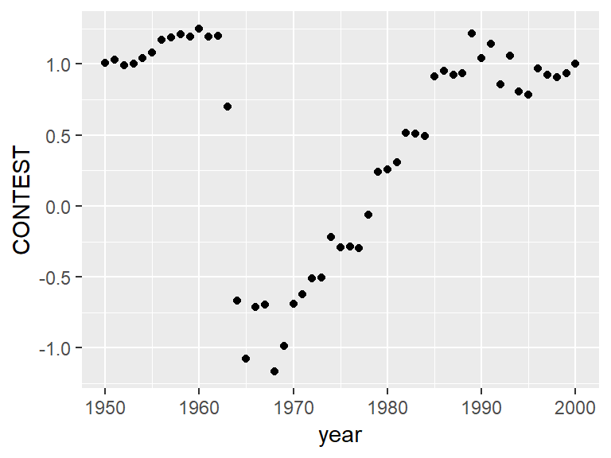

```r
library(haven)
library(ggplot2)
setwd("C:\\Users\\Alessandro Freire\\Downloads")
dahl <- read_spss("DahlDims.sav")

dahl_brasil <- dahl[dahl$abbr == "BRZL",]
ggplot(dahl_brasil, aes(x = year, y = CONTEST)) + geom_point()
```

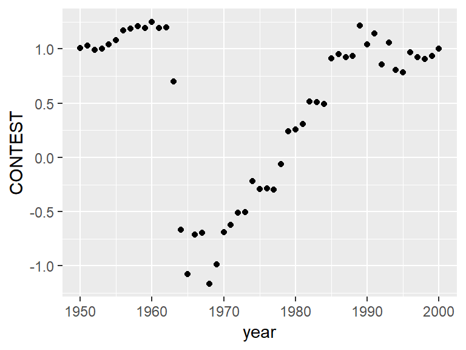

```r
dahl %>%
  filter(abbr == "BRZL") %>%
ggplot(aes(x = year, y = CONTEST)) + geom_point()
```

# O Pacote dplyr

- O pacote dplyr inclui uma série de funções que simplificam a programação.
- É um pacote excelente para a manipulação de dados.
- Algumas das principais funções do dplyr são: filter, arrange, select, mutate, group_by e summarise.

# Filter

- A função `filter()` é equivalente ao uso de `[]` para selecionar valores de variáveis e à função `subset()`.
- Uma das principais vantagens da função `filter()` em relação ao uso de `[]` e à função `subset()` é que ela é mais rápida quando estamos lidando com básicos de dados maiores. Além disso, ela também permite operar em SQL sem exigir que os dados sejam carregados na memória.
- O primeiro argumento da função `filter()` corresponde ao dataframe e o segundo argumento corresponde à variável de interesse.
- Note que não precisamos repetir o nome da base de dados quando estamos usando o operador pipe porque o R entende que o comando seguinte se refere ao objeto `dahl`.
- Se quisermos apenas os dados a partir do ano de 1960 para o Afeganistão da base de dados `dahl`, podemos usar:

```r
dahl %>%
  filter(abbr == "AFGN" & year >= 1960) %>%
  head(3)
```

```
## # A tibble: 3 x 28
##   cname abbr   year    yr CONTEST INCLUS CONTESTstd INCLUSstd ContestationA
##   <chr> <chr> <dbl> <dbl>   <dbl>  <dbl>      <dbl>     <dbl>         <dbl>
## 1 Afgh~ AFGN   1960    60  -1.01  -0.504      -1.03    -0.374        -1.01
## 2 Afgh~ AFGN   1961    61  -0.970 -0.514      -1.01    -0.398        -0.970
## 3 Afgh~ AFGN   1962    62  -0.958 -0.453      -1.03    -0.388        -0.958
## # ... with 19 more variables: INCLUSA <dbl>, CONTESTB <dbl>,
## #   INCLUSB <dbl>, CONTESTC <dbl>, INCLUSC <dbl>, CRSUFF <dbl>,
## #   FAIRELT <dbl>, FREEORG <dbl>, FREXP <dbl>, ALTINF <dbl>, POLY <dbl>,
## #   ccode <dbl>, ccodecow <dbl>, ccodealp <chr>, ccodewb <chr>,
## #   f1mean <dbl>, f2mean <dbl>, f1sd <dbl>, f2sd <dbl>
```

- Cabe notar que o comando anterior NÃO gera uma nova base de dados no ambiente global do R.
- Ou seja, se quisermos que a nova base de dados apareça no ambiente global, devemos criar um novo objeto, usando o sinal `<-`.

```r
dahl_afg_1960 <- dahl %>%
  filter(abbr == "AFGN" & year >= 1960)
  head(dahl_afg_1960)
```

```
## # A tibble: 6 x 28
##   cname abbr   year    yr CONTEST INCLUS CONTESTstd INCLUSstd ContestationA
##   <chr> <chr> <dbl> <dbl>   <dbl>  <dbl>      <dbl>     <dbl>         <dbl>
## 1 Afgh~ AFGN   1960    60  -1.01  -0.504     -1.03     -0.374        -1.01
## 2 Afgh~ AFGN   1961    61  -0.970 -0.514     -1.01     -0.398        -0.970
## 3 Afgh~ AFGN   1962    62  -0.958 -0.453     -1.03     -0.388        -0.958
## 4 Afgh~ AFGN   1963    63  -0.949 -0.410     -1.04     -0.368        -0.949
## 5 Afgh~ AFGN   1964    64  -1.01  -1.51      -1.11     -1.60         -1.01
## 6 Afgh~ AFGN   1965    65  -0.504 -0.145     -0.579    -0.108        -0.504
## # ... with 19 more variables: INCLUSA <dbl>, CONTESTB <dbl>,
## #   INCLUSB <dbl>, CONTESTC <dbl>, INCLUSC <dbl>, CRSUFF <dbl>,
## #   FAIRELT <dbl>, FREEORG <dbl>, FREXP <dbl>, ALTINF <dbl>, POLY <dbl>,
## #   ccode <dbl>, ccodecow <dbl>, ccodealp <chr>, ccodewb <chr>,
## #   f1mean <dbl>, f2mean <dbl>, f1sd <dbl>, f2sd <dbl>
```

# Arrange

- A função `arrange()` ordena os dados de um dataframe.
- O primeiro argumento da função corresponde ao dataframe e o segundo à variável (ou variáveis) a partir da qual se deseja ordenar uma base de dados. Caso queiramos ordenar os dados em ordem descresente, podemos usar a função `desc()`.

```r
dahl %>%
  filter(abbr == "BRZL") %>%
  select(year, CONTEST) %>%
  arrange(CONTEST)
```

```
## # A tibble: 51 x 2
##     year CONTEST
##    <dbl>   <dbl>
##  1  1968  -1.17
##  2  1965  -1.07
##  3  1969  -0.988
##  4  1966  -0.713
##  5  1967  -0.697
##  6  1970  -0.689
##  7  1964  -0.670
##  8  1971  -0.620
##  9  1972  -0.508
## 10  1973  -0.506
## # ... with 41 more rows
```

- Cabe lembrar que o padrão de ordenamento da função `arrange()` é ascendente.

```r
dahl %>%
  arrange(year, CONTEST) %>%
  head()
```

```
## # A tibble: 6 x 28
##   cname abbr   year    yr CONTEST INCLUS CONTESTstd INCLUSstd ContestationA
##   <chr> <chr> <dbl> <dbl>   <dbl>  <dbl>      <dbl>     <dbl>         <dbl>
## 1 China CHNA   1950    50   -1.62 -1.37       -1.48    -1.03          -1.62
## 2 Saud~ SDAR   1950    50   -1.57 -3.19       -1.43    -2.52          -1.57
## 3 Ethi~ ETHP   1950    50   -1.46 -0.741      -1.32    -0.517         -1.46
## 4 Nepal NPAL   1950    50   -1.41 -3.45       -1.28    -2.74          -1.41
## 5 Yeme~ YMNN   1950    50   -1.35 -2.46       -1.21    -1.93          -1.35
## 6 Vene~ VNZL   1950    50   -1.32 -2.34       -1.18    -1.83          -1.32
## # ... with 19 more variables: INCLUSA <dbl>, CONTESTB <dbl>,
## #   INCLUSB <dbl>, CONTESTC <dbl>, INCLUSC <dbl>, CRSUFF <dbl>,
## #   FAIRELT <dbl>, FREEORG <dbl>, FREXP <dbl>, ALTINF <dbl>, POLY <dbl>,
## #   ccode <dbl>, ccodecow <dbl>, ccodealp <chr>, ccodewb <chr>,
## #   f1mean <dbl>, f2mean <dbl>, f1sd <dbl>, f2sd <dbl>
```

# Mutate

- A função `mutate()` cria novas variáveis em um dataframe.

```r
library(gapminder)

gapminder %>%
  mutate(gdp = gdpPercap*pop)
```

```
## # A tibble: 1,704 x 7
##    country     continent  year lifeExp      pop gdpPercap          gdp
##    <fct>       <fct>     <int>   <dbl>    <int>     <dbl>        <dbl>
##  1 Afghanistan Asia       1952    28.8  8425333      779.  6567086330.
##  2 Afghanistan Asia       1957    30.3  9240934      821.  7585448670.
##  3 Afghanistan Asia       1962    32.0 10267083      853.  8758855797.
##  4 Afghanistan Asia       1967    34.0 11537966      836.  9648014150.
##  5 Afghanistan Asia       1972    36.1 13079460      740.  9678553274.
##  6 Afghanistan Asia       1977    38.4 14880372      786. 11697659231.
##  7 Afghanistan Asia       1982    39.9 12881816      978. 12598563401.
##  8 Afghanistan Asia       1987    40.8 13867957      852. 11820990309.
##  9 Afghanistan Asia       1992    41.7 16317921      649. 10595901589.
## 10 Afghanistan Asia       1997    41.8 22227415      635. 14121995875.
## # ... with 1,694 more rows
```

- Naturalmente, podemos criar mais de uma variável.

```r
library(nycflights13)

flights %>%
  mutate(total_delay = dep_delay + arr_delay,
         avg_speed = distance/air_time) %>%
  select(total_delay, avg_speed)
```

```
## # A tibble: 336,776 x 2
##    total_delay avg_speed
##          <dbl>     <dbl>
##  1          13      6.17
##  2          24      6.24
##  3          35      6.81
##  4         -19      8.61
##  5         -31      6.57
##  6           8      4.79
##  7          14      6.74
##  8         -17      4.32
##  9         -11      6.74
## 10           6      5.31
## # ... with 336,766 more rows
```

- A função `transmute()` é uma variação da função `mutate()`. A diferença é que `transmute()`deleta todas as demais variáveis e mantém apenas as que foram criadas.
- É uma função ideal para quando queremos criar um novo dataframe.
- Note que, se quisermos manter uma variável do banco de dados anterior, basta digitar o seu nome dentro do comando `transmute`.

```r
flights %>%
  transmute(year, total_delay = dep_delay + arr_delay,
         avg_speed = distance/air_time) %>%
  head()
```

```
## # A tibble: 6 x 3
##    year total_delay avg_speed
##   <int>       <dbl>     <dbl>
## 1  2013          13      6.17
## 2  2013          24      6.24
## 3  2013          35      6.81
## 4  2013         -19      8.61
## 5  2013         -31      6.57
## 6  2013           8      4.79
```

# Select

- A função `select()` seleciona variáveis de um dataframe.

```r
dahl %>%
  select(year, CONTEST) %>%
  summary()
```

```
##       year         CONTEST
##  Min.   :1950   Min.   :-2.066589
##  1st Qu.:1967   1st Qu.:-0.876475
##  Median :1980   Median :-0.214421
##  Mean   :1978   Mean   :-0.004748
##  3rd Qu.:1991   3rd Qu.: 0.918339
##  Max.   :2000   Max.   : 1.908944
##                 NA's   :29
```

- Podemos usar os argumentos `starts_with()`, `ends_with()` e `contains()` se quisermos selecionar variáveis com nomes específicos.

```r
setwd("C:\\Users\\Alessandro Freire\\Downloads")
democracy <- read_spss("Democracy.sav")

democracy %>%
select(starts_with("cpi")) %>%
  head()
```

```
## # A tibble: 6 x 10
##   cpi8085 cpi8892 cpi1996 cpi2001 cpi2002 cpi2003 cpi2004 cpi2005 cpi2006
##     <dbl>   <dbl>   <dbl>   <dbl>   <dbl>   <dbl>   <dbl>   <dbl>   <dbl>
## 1      NA      NA      NA      NA   NA       NA      NA      2.51    NA
## 2      NA      NA      NA      NA    2.5      2.5     2.5    2.42     2.6
## 3      NA      NA      NA      NA   NA        2.6     2.7    2.84     3.1
## 4      NA      NA      NA      NA   NA       NA      NA      7.70    NA
## 5      NA      NA      NA      NA    1.70     1.8     2      2.02     2.2
## 6      NA      NA      NA      NA   NA       NA      NA      4.61    NA
## # ... with 1 more variable: cpi2007 <dbl>
```

```r
democracy %>%
select(ends_with("mean")) %>%
  head()
```

```
## # A tibble: 6 x 24
##   EconGlob_mean SocGlob_mean PolGlob_mean mediause_mean Newspaper_mean
##           <dbl>        <dbl>        <dbl>         <dbl>          <dbl>
## 1          NA           NA           NA            NA           NA
## 2          32.3         14.9         12.6          NA           NA
## 3          35.5         20.2         36.3          NA           NA
## 4          NA           NA           NA            63.4          0.852
## 5          NA           NA           NA            NA           NA
## 6          NA           NA           NA            NA           NA
## # ... with 19 more variables: Radio_TV_Mean <dbl>, internet_mean <dbl>,
## #   magazine_mean <dbl>, books_mean <dbl>, nomedia_mean <dbl>,
## #   conpress_mean <dbl>, conTV_mean <dbl>, nationalist100_mean <dbl>,
## #   globgov100_mean <dbl>, trustothers100_mean <dbl>,
## #   socconform100_mean <dbl>, Success100_mean <dbl>,
## #   markets100_mean <dbl>, socconform_mean <dbl>, SUCCESS_mean <dbl>,
## #   ECONCOMP_mean <dbl>, INCENTIVES_mean <dbl>, LEFTRIGHT100_mean <dbl>,
## #   genderequality_mean <dbl>
```

```r
democracy %>%
select(contains("press")) %>%
  head()
```

```
## # A tibble: 6 x 14
##   FreePress2004 FreePress2005 FreePress2006 FreePress2004rev
##           <dbl>         <dbl>         <dbl>            <dbl>
## 1            28            68            69               72
## 2            51            51            50               49
## 3            37            64            61               63
## 4            87            14            14               13
## 5            34            66            65               66
## 6            57            40            38               43
## # ... with 10 more variables: Freepress2005rev <dbl>,
## #   Freepress2006rev <dbl>, ZFreepress2006rev <dbl>, conpress_mean <dbl>,
## #   Statepressbycount <dbl>, Privatepressbycount <dbl>,
## #   Otherpressbycount <dbl>, Statepressbyshare <dbl>,
## #   Privatepressbyshare <dbl>, Otherpressbyshare <dbl>
```

# Summarise

- A função `summarise()` fornece estatísticas sumárias definidas pelo próprio usuário.

```r
dahl %>%
  filter(!is.na(CONTEST)) %>%
  summarise(cont_mean = mean(CONTEST),
            cont_sd = sd(CONTEST),
            cont_max = max(CONTEST))
```

```
## # A tibble: 1 x 3
##   cont_mean cont_sd cont_max
##       <dbl>   <dbl>    <dbl>
## 1  -0.00475    1.01     1.91
```

# Group by

- A função `group_by()` agrupa os dados a partir de variáveis selecionadas.
- Essa é uma função essencial, pois nos poupa muito tempo com comandos desnecessários e repetitivos.
- Por exemplo, se quiséssemos a média, o desvio-padrão e o valor máximo de `CONTEST` para cada país usando o R básico, poderíamos fazer “à mão” da seguinte forma:

```r
cont_mean <- mean(dahl$CONTEST[dahl$cname=="Afghanistan"], na.rm = T)
cont_sd <- sd(dahl$CONTEST[dahl$cname=="Afghanistan"], na.rm = T)
cont_max <- max(dahl$CONTEST[dahl$cname=="Afghanistan"], na.rm = T)
```

- É evidente que esse método é extremamente tedioso, lento e ineficiente.
- Usando a função `group_by()` simplificamos a tarefa:

```r
dahl %>%
  filter(!is.na(CONTEST)) %>%
  group_by(cname) %>%
  summarise(cont_mean = mean(CONTEST),
            cont_sd = sd(CONTEST),
            cont_max = max(CONTEST))
```

```
## # A tibble: 202 x 4
##    cname               cont_mean cont_sd cont_max
##    <chr>                   <dbl>   <dbl>    <dbl>
##  1 Afghanistan           -1.02     0.393   -0.310
##  2 Albania               -0.802    0.473    0.332
##  3 Algeria               -0.991    0.244   -0.459
##  4 Andorra                0.137    0.180    0.554
##  5 Angola                -1.05     0.267   -0.711
##  6 Antigua and Barbuda    0.382    0.246    0.818
##  7 Argentina              0.0960   0.864    1.31
##  8 Armenia                0.112    0.327    0.615
##  9 Australia              1.56     0.178    1.87
## 10 Austria                1.44     0.306    1.80
## # ... with 192 more rows
```

- Note que, no exemplo anterior, se tentássemos agrupar os dados **depois** de calcular as estatísticas, o R nos retornaria um erro.

```r
dahl %>%
  filter(!is.na(CONTEST)) %>%
  summarise(cont_mean = mean(CONTEST),
            cont_sd = sd(CONTEST),
            cont_max = max(CONTEST)) %>%
  group_by(cname)
```

```
## Error in grouped_df_impl(data, unname(vars), drop): Column `cname` is unknown
```

- Isso ocorre porque já não estamos manipulando o dataframe original, mas sim um objeto com três elementos.

# Count

- A função `count()` conta o número de observações em um ou mais grupos.

```r
dahl %>%
  filter(year >= 1970) %>%
  count(cname)
```

```
## # A tibble: 203 x 2
##    cname                   n
##    <chr>               <int>
##  1 Afghanistan            31
##  2 Albania                31
##  3 Algeria                31
##  4 Andorra                31
##  5 Angola                 26
##  6 Antigua and Barbuda    20
##  7 Argentina              31
##  8 Armenia                12
##  9 Australia              31
## 10 Austria                31
## # ... with 193 more rows
```

# Salvando objetos

- Podemos querer salvar um objeto em meio a uma série de comandos executados com o operador pipe.
- Nesses casos, usamos o sinal de atribução invertido (->) e invertemos a ordem de comando e nome do objeto.

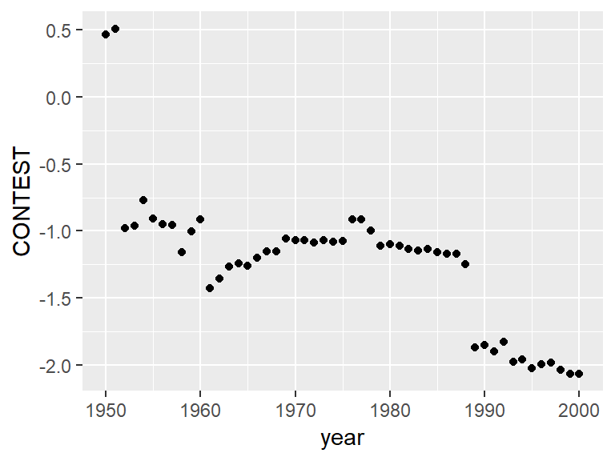

```r
dahl %>%
  filter(cname == "Cuba") %>%
  ggplot(aes(x = year, y = CONTEST)) + geom_point() -> cuba_plot
  cuba_plot
```

```r
 dahl %>%
  filter(year == 1990) %>%
  lm(CONTEST ~ INCLUS, data = .) %>%
  summary() -> model_1990_summary
  model_1990_summary
```

```
##
## Call:
## lm(formula = CONTEST ~ INCLUS, data = .)
##
## Residuals:
##     Min      1Q  Median      3Q     Max
## -2.0320 -0.5968  0.0000  0.6865  1.6247
##
## Coefficients:
##               Estimate Std. Error t value Pr(>|t|)
## (Intercept) -1.492e-16  6.194e-02   0.000        1
## INCLUS       5.450e-01  6.099e-02   8.936 3.62e-16 ***
## ---
## Signif. codes:  0 '***' 0.001 '**' 0.01 '*' 0.05 '.' 0.1 ' ' 1
##
## Residual standard error: 0.856 on 189 degrees of freedom
## Multiple R-squared:  0.297,  Adjusted R-squared:  0.2933
## F-statistic: 79.85 on 1 and 189 DF,  p-value: 3.619e-16
```

# Exercícios

1. Reproduza os resultados dos comandos abaixo, feitos com o R básico, usando o operador pipe e o dplyr. Não é necessário que a base de dados `dahl_subset` apareça no ambiente global do R. Obs: Não se esqueça de salvar o gráfico como `cont_inclus_plot`.

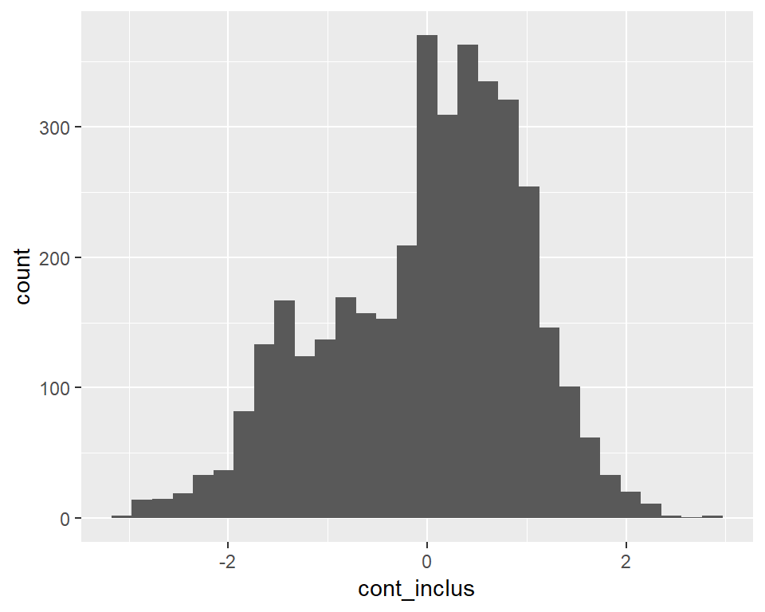

```r
dahl_subset <- dahl[dahl$year>=1980,]
dahl_subset$cont_inclus <- (dahl_subset$CONTEST - dahl_subset$INCLUS)
cont_inclus_plot <- ggplot(dahl_subset, aes(x=cont_inclus)) +
  geom_histogram()
cont_inclus_plot
```

2. Usando a base de dados `dahl()`:
- Use um filtro com valores de `INCLUS` iguais ou superiores a 1.
- Agrupe os dados por país (`cname`).
- Calcule a média (`mean_inclus`), o desvio-padrão (`sd_inclus`) da variável `INCLUS` e a mediana (`median_inclus`). Obs: para calcular `median_inclus` basta usar a função `median()`.
- Ordene os dados da maior para a menor média de `INCLUS`.
- Qual o país com a maior média de `INCLUS`?
3. Usando a base de dados `democracy`:
- Selecione apenas as variáveis as que contêm “fh” em seus nomes.
- Agrupe os dados por país (`NatFH`).
- Calcule o valor mínimo da variável `Fhstand2000` (`min_fh2000`).
- Ordene os dados em ordem ascendente a partir de `min_fh2000`.
- Quais os seis países com os menores valores de `Fhstand2000`? E quais os países com os maiores valores?
4. Usando a base de dados `democracy`:
- Selecione as variáveis `Nation` e as que começam com “Women”.
- Crie uma nova variável chamada `Women_Diff` a partir da diferença entre `Women2008` e `Women1990` mantendo a variável `Nation` e excluindo as demais variáveis.
- Ordene os dados em ordem decrescente.
- Qual país apresentou a maior evolução da participação da mulher na política entre 1990 e 2008?